# EE550 HW3 Multi Layer Perceptron

Erhan Can Ozcan

2/4/2019

In this project, we are asked to implement a generic multilayer perceptron model. To deal with the convergence issues, some adaptive learning approaches are utilized. Basically, step length and momentum coefficient are two parameters used to solve convergence issues. At each epoch, training samples are shuffled to avoid convergence to local minimum. In the code, an additional neuron is added for threshold in the output layer.

## 1) Question 1 (XOR Function)

### 1.a Number of Layers=3

A 3 layered network is constructed. Number of neurons in hidden layer is 9, step length is selected as 2, momentum coefficient is 0.2. Step length is adjusted according to the evolution of total error from epoch to epoch. Finally, learning stops when the total training error becomes less than 0.001

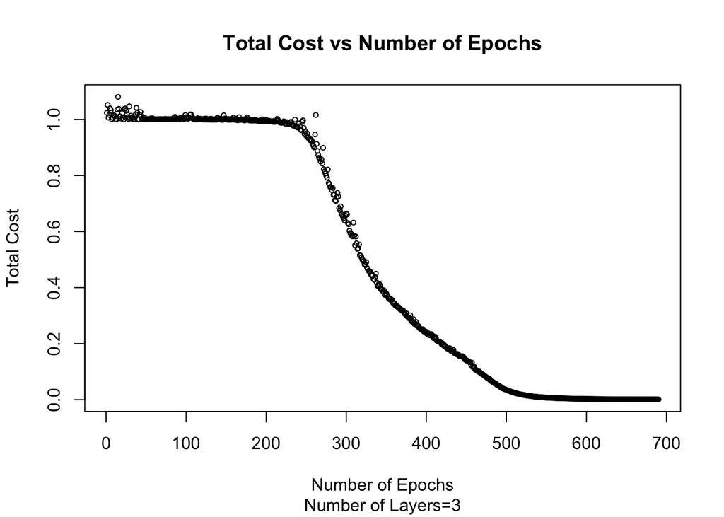

real output for each sample = [ 0, 1, 0, 1 ]

predictions for each sample = [ 0.01808, 0.98498, 0.01478, 0.98502 ]

### 1.b Number of Layers=4

A 4 layered network is constructed. Number of neurons in each hidden layer is 9, step length is selected as 2, momentum coefficient is 0.2. Step length is adjusted according to the evolution of total error from epoch to epoch. Finally, learning stops when the total training error becomes less than 0.001

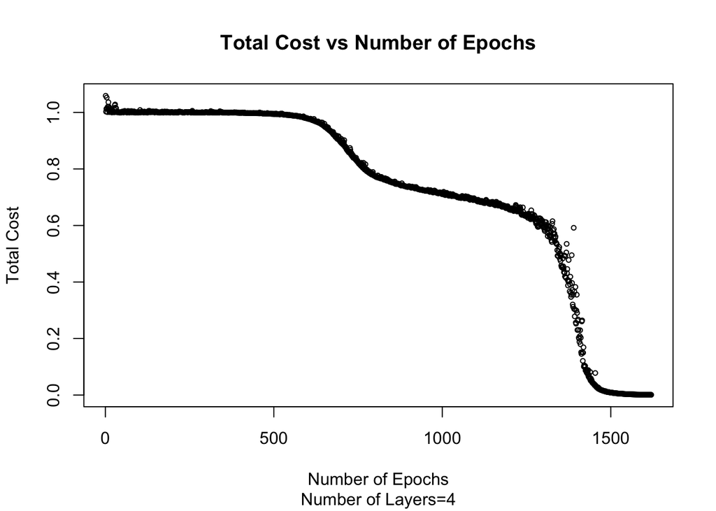

real output for each sample = [ 0, 0, 1, 1 ]

predictions for each sample = [ 0.00224, 0.01613, 0.9805, 0.98162 ]

## 2) Question 2 (Sin(x) Function)

First of all, 60 data points ~U[0,1] are produced. Then, these data points are multiplied by 2*$\pi$. Y value for each data point is calculated via Sin(x) function. Since Sin(x) function can take values between -1 and 1, unlike the other two questions, hyperbolic tangent function is utilized as an activation function in this question.

### 2.a Number of Layers=3

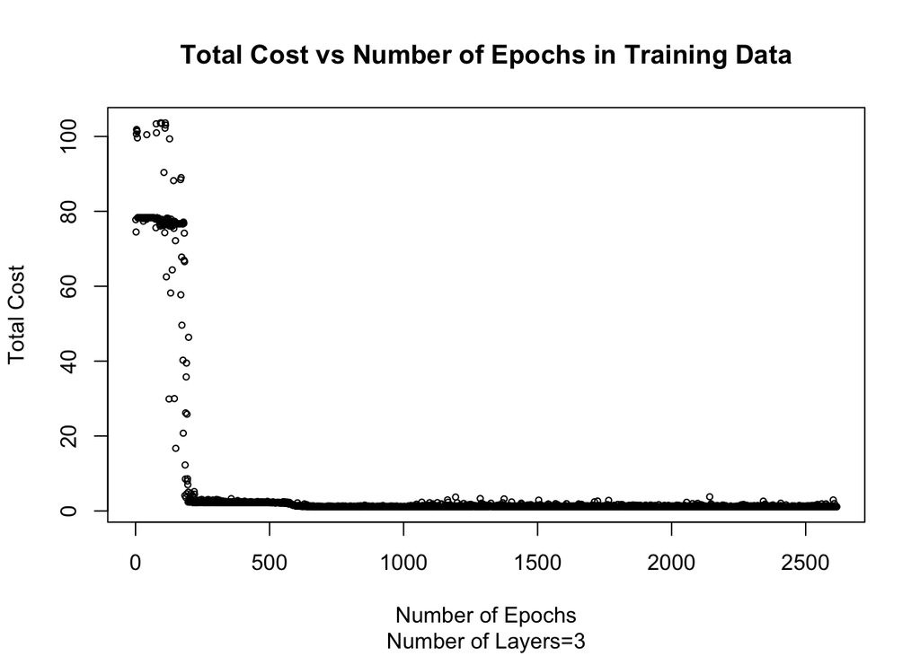

#### Test with 25 new samples

Finally, additional 25 points are generated from U[0,1]. Through using the trained model, y values of these newly generated points are predicted. From the plot below, you can see the real and predicted value of each data point.

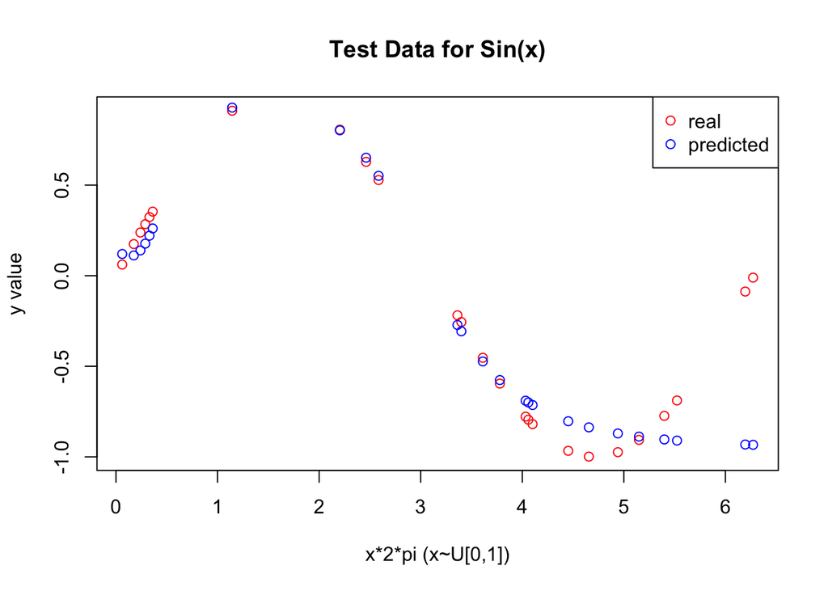

### 2.b Number of Layers=4

A 4 layered network is constructed. Number of neurons in each hidden layer is 10, step length is selected as 1.2, momentum coefficient is 0.2. Step length is adjusted according to the evolution of total error from epoch to epoch. Finally, learning stops when the total training error becomes less than 0.15. From the graph below, you can observe the improvement of cost function.

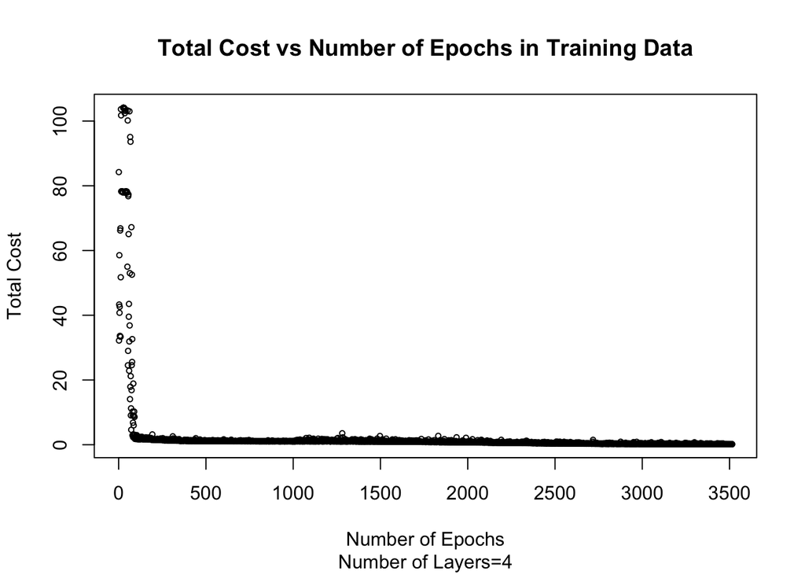

#### Test with 25 new samples

Finally, additional 25 points are generated from U[0,1]. Through using the trained model, y values of these newly generated points are predicted. From the plot below, you can see the real and predicted value of each data point.

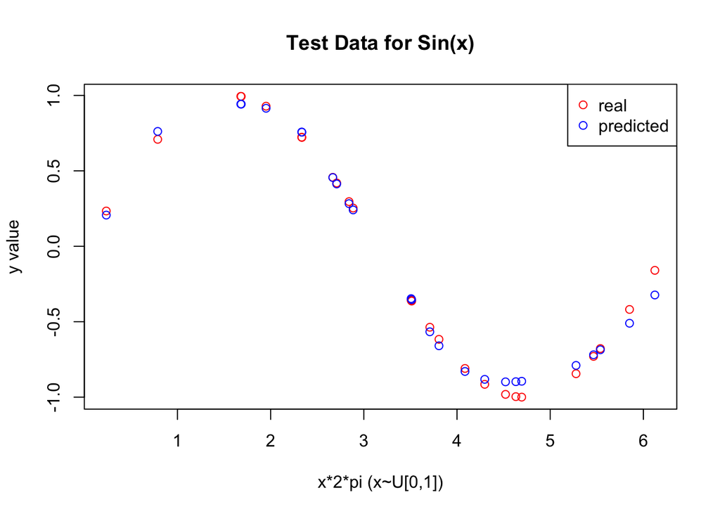

## 3) Question 3 (Iris Data Set)

Iris Data set contains 150 samples. 125 of them are chosen as training samples randomly, and remaining ones are used as test samples. ANN model is used to predict the class of each sample. At each layer of the model, sigmoid function is utilized as an activation function. In this model, there are 3 output layers.

### 3.a Number of Layers=3

A 3 layered network is constructed. Number of neurons in hidden layer is 10, step length is selected as 1, momentum coefficient is 0.2. Step length is adjusted according to the evolution of total error from epoch to epoch. Finally, learning stops when the total training error becomes less than 3.

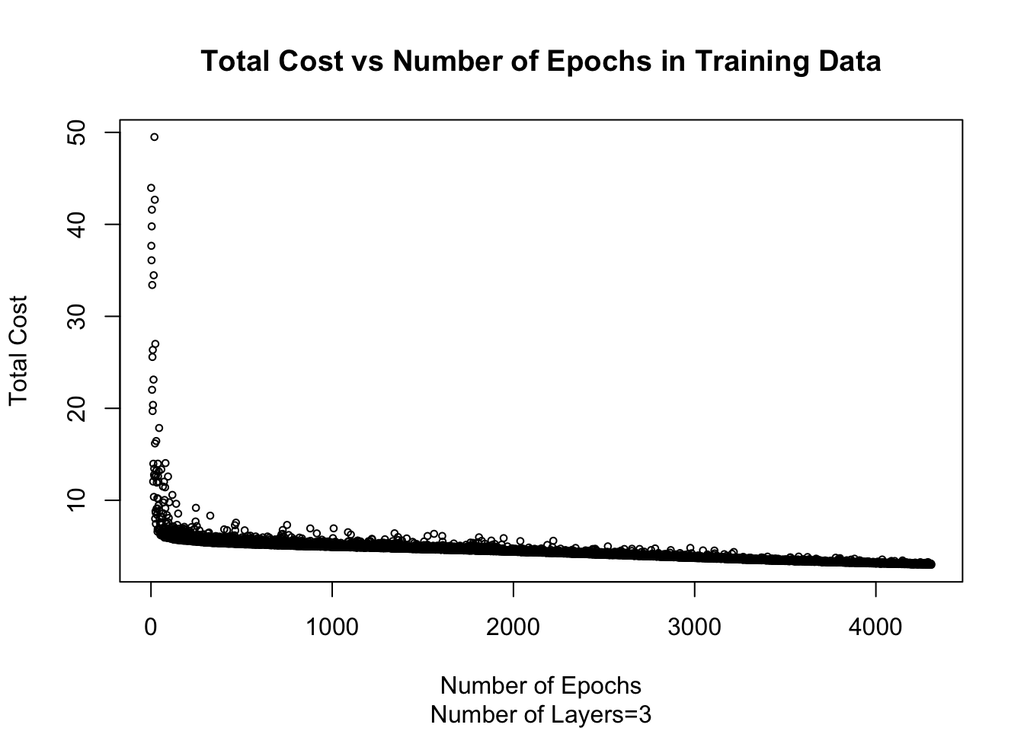

#### Test of remaining points

Firstly, let’s check the relation between the inputs and real outputs for test data.

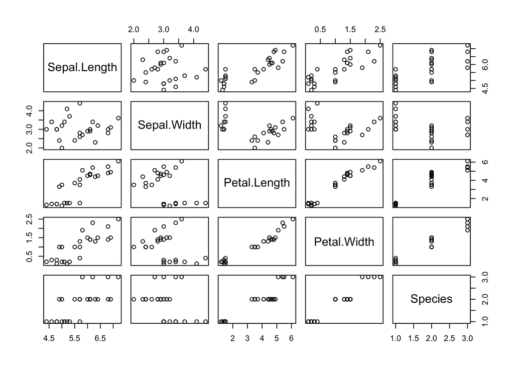

From the last column of the above graph, it can be observed that selected test samples are well seperated. Same data points are used in 2 models, and the input of test data can be seen from the table below.

|  | Sepal.Length | Sepal.Width | Petal.Length | Petal.Width |
| --- | --- | --- | --- | --- |
| 77 | 6.8 | 2.8 | 4.8 | 1.4 |
| 46 | 4.8 | 3.0 | 1.4 | 0.3 |
| 64 | 6.1 | 2.9 | 4.7 | 1.4 |
| 102 | 5.8 | 2.7 | 5.1 | 1.9 |
| 13 | 4.8 | 3.0 | 1.4 | 0.1 |
| 33 | 5.2 | 4.1 | 1.5 | 0.1 |
| 40 | 5.1 | 3.4 | 1.5 | 0.2 |
| 39 | 4.4 | 3.0 | 1.3 | 0.2 |
| 88 | 6.3 | 2.3 | 4.4 | 1.3 |
| 61 | 5.0 | 2.0 | 3.5 | 1.0 |
| 92 | 6.1 | 3.0 | 4.6 | 1.4 |
| 79 | 6.0 | 2.9 | 4.5 | 1.5 |
| 16 | 5.7 | 4.4 | 1.5 | 0.4 |
| 82 | 5.5 | 2.4 | 3.7 | 1.0 |
| 49 | 5.3 | 3.7 | 1.5 | 0.2 |
| 58 | 4.9 | 2.4 | 3.3 | 1.0 |
| 7 | 4.6 | 3.4 | 1.4 | 0.3 |
| 36 | 5.0 | 3.2 | 1.2 | 0.2 |
| 53 | 6.9 | 3.1 | 4.9 | 1.5 |
| 110 | 7.2 | 3.6 | 6.1 | 2.5 |
| 113 | 6.8 | 3.0 | 5.5 | 2.1 |
| 80 | 5.7 | 2.6 | 3.5 | 1.0 |
| 100 | 5.7 | 2.8 | 4.1 | 1.3 |
| 149 | 6.2 | 3.4 | 5.4 | 2.3 |
| 52 | 6.4 | 3.2 | 4.5 | 1.5 |

25 data points above are classified through trained ANN model. We have 3 outputs for each sample, to be able to treat these outputs as probability we should normalize or transform them. We can conduct this operation using the formula below.
$$p_i=\frac{X_i}{\sum_{i=1}^3 X_i}$$
In addition to this, I could have used soft max as activation function in the output layer. This activation function ensures that sum of the outputs in the next layer is 1. However, I used sigmoid function, and transformed the outputs for each sample by using the formula above.

The real labels(last 3 column in the table) and predicted labels(first 3 column in the table) can be seen from the table below.

| V1 | V2 | V3 | setosa | versicolor | virginica |
| --- | --- | --- | --- | --- | --- |
| 0.0005474 | 0.9992826 | 0.0001700 | 0 | 1 | 0 |
| 0.9767764 | 0.0232236 | 0.0000000 | 1 | 0 | 0 |
| 0.0012359 | 0.9965126 | 0.0022516 | 0 | 1 | 0 |
| 0.0006856 | 0.0162318 | 0.9830826 | 0 | 0 | 1 |
| 0.9771481 | 0.0228519 | 0.0000000 | 1 | 0 | 0 |
| 0.9835637 | 0.0164363 | 0.0000000 | 1 | 0 | 0 |
| 0.9804275 | 0.0195725 | 0.0000000 | 1 | 0 | 0 |
| 0.9780482 | 0.0219518 | 0.0000000 | 1 | 0 | 0 |
| 0.0004120 | 0.9988364 | 0.0007516 | 0 | 1 | 0 |
| 0.0006810 | 0.9991804 | 0.0001386 | 0 | 1 | 0 |
| 0.0032303 | 0.9967087 | 0.0000610 | 0 | 1 | 0 |
| 0.0018731 | 0.9975107 | 0.0006162 | 0 | 1 | 0 |
| 0.9840615 | 0.0159385 | 0.0000000 | 1 | 0 | 0 |
| 0.0033674 | 0.9966311 | 0.0000015 | 0 | 1 | 0 |
| 0.9821664 | 0.0178336 | 0.0000000 | 1 | 0 | 0 |
| 0.0155210 | 0.9844788 | 0.0000001 | 0 | 1 | 0 |
| 0.9808302 | 0.0191698 | 0.0000000 | 1 | 0 | 0 |
| 0.9802247 | 0.0197753 | 0.0000000 | 1 | 0 | 0 |
| 0.0013880 | 0.9985909 | 0.0000211 | 0 | 1 | 0 |
| 0.0007557 | 0.0134123 | 0.9858320 | 0 | 0 | 1 |
| 0.0006833 | 0.0195318 | 0.9797849 | 0 | 0 | 1 |
| 0.0213206 | 0.9786793 | 0.0000000 | 0 | 1 | 0 |
| 0.0064583 | 0.9935391 | 0.0000026 | 0 | 1 | 0 |
| 0.0013352 | 0.0194882 | 0.9791767 | 0 | 0 | 1 |
| 0.0115729 | 0.9884265 | 0.0000006 | 0 | 1 | 0 |

We can see that all the samples in the test data are classified correctly.

### 3.b Number of Layers=4

A 4 layered network is constructed. Number of neurons in each hidden layer is 10 and 12 respectively. Step length is selected as 1, momentum coefficient is 0.2. Step length is adjusted according to the evolution of total error from epoch to epoch. Finally, learning stops when the total training error becomes less than 3.

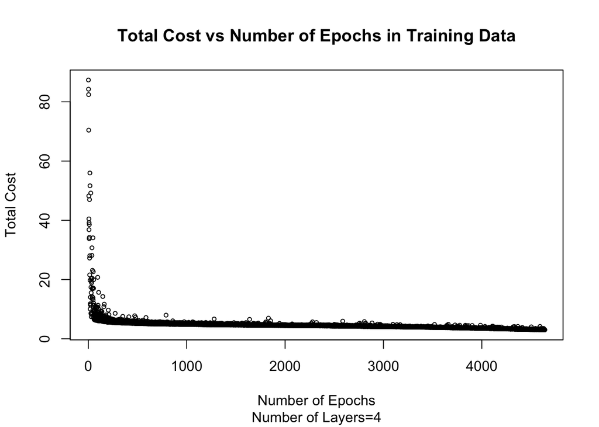

#### Test of remaining points

Remaining 25 data points are classified through trained ANN model. We have 3 outputs for each sample, to be able to treat these outputs as probability we should normalize or transform them. We can conduct this operation using the formula below.
$$p_i=\frac{X_i}{\sum_{i=1}^3 X_i}$$
In addition to this, I could have used soft max as activation function in the output layer. This activation function ensures that sum of the outputs in the next layer is 1. However, I used sigmoid function, and transformed the outputs for each sample by using the formula above.

The real labels(last 3 column in the table) and predicted labels(first 3 column in the table) can be seen from the table below.

| V1 | V2 | V3 | setosa | versicolor | virginica |
| --- | --- | --- | --- | --- | --- |
| 0.0026067 | 0.9973783 | 0.0000151 | 0 | 1 | 0 |
| 0.9873213 | 0.0126787 | 0.0000000 | 1 | 0 | 0 |
| 0.0017185 | 0.9982173 | 0.0000642 | 0 | 1 | 0 |
| 0.0003272 | 0.0141498 | 0.9855230 | 0 | 0 | 1 |
| 0.9871410 | 0.0128590 | 0.0000000 | 1 | 0 | 0 |
| 0.9928981 | 0.0071019 | 0.0000000 | 1 | 0 | 0 |
| 0.9905437 | 0.0094563 | 0.0000000 | 1 | 0 | 0 |
| 0.9892890 | 0.0107110 | 0.0000000 | 1 | 0 | 0 |
| 0.0017614 | 0.9981902 | 0.0000485 | 0 | 1 | 0 |
| 0.0025748 | 0.9974095 | 0.0000157 | 0 | 1 | 0 |
| 0.0037564 | 0.9962369 | 0.0000067 | 0 | 1 | 0 |
| 0.0023677 | 0.9976099 | 0.0000224 | 0 | 1 | 0 |
| 0.9931039 | 0.0068961 | 0.0000000 | 1 | 0 | 0 |
| 0.0071304 | 0.9928679 | 0.0000017 | 0 | 1 | 0 |
| 0.9918803 | 0.0081197 | 0.0000000 | 1 | 0 | 0 |
| 0.0103211 | 0.9896779 | 0.0000010 | 0 | 1 | 0 |
| 0.9915186 | 0.0084814 | 0.0000000 | 1 | 0 | 0 |
| 0.9898913 | 0.0101087 | 0.0000000 | 1 | 0 | 0 |
| 0.0043344 | 0.9956609 | 0.0000047 | 0 | 1 | 0 |
| 0.0003329 | 0.0158130 | 0.9838540 | 0 | 0 | 1 |
| 0.0003517 | 0.0234743 | 0.9761741 | 0 | 0 | 1 |
| 0.0128948 | 0.9871045 | 0.0000007 | 0 | 1 | 0 |
| 0.0064037 | 0.9935941 | 0.0000022 | 0 | 1 | 0 |
| 0.0003339 | 0.0168790 | 0.9827871 | 0 | 0 | 1 |
| 0.0084614 | 0.9915373 | 0.0000013 | 0 | 1 | 0 |

We can see that all the samples in the test data are classified correctly.

# Code

## Q1

```r
#'EE550 HW3 Q1 MLP for XOR

#Set the inputs----
momentum_coef=0.2
error_threshold=0.001
set.seed(10)
step_length=2
no_of_hidden_layers=2
#no_of_hidden_layers=1
no_of_neurons_in_hidden_layers=c(9,9)
#no_of_neurons_in_hidden_layers=c(9)
no_of_outputs=1
input<-matrix(c(0,0,0,1,1,0,1,1),nrow=4,byrow=TRUE)
desired_t<-matrix(c(0,1,1,0),nrow=4)
##end----

#initialization----
no_of_data_points=nrow(input)
no_of_input_neurons=ncol(input)
neurons_in_layers=no_of_input_neurons
i=2
for (i in 1:no_of_hidden_layers ){
  neurons_in_layers<-c(neurons_in_layers,no_of_neurons_in_hidden_layers[i])
}
neurons_in_layers<-c(neurons_in_layers,no_of_outputs)


col_w=neurons_in_layers[2]
row_w=neurons_in_layers[1]

weights<-list(matrix(rnorm(col_w*row_w,0,0.1),nrow=row_w))
for (i in 2:(length(neurons_in_layers)-1)){
  col_w=neurons_in_layers[i+1]
  row_w=neurons_in_layers[i]
  tmp<-matrix(rnorm(col_w*row_w,0,0.1),nrow=row_w)
  weights[[i]]<-tmp

}
no_of_weight_matrices=length(weights)
threshold=rnorm(1,sd=0.2)

col_w=neurons_in_layers[2]
row_w=neurons_in_layers[1]
tmp_old_up=col_w*row_w
old_update<-list(matrix(rep(0,tmp_old_up),nrow=row_w))
for (i in 2:(length(neurons_in_layers)-1)){
  col_w=neurons_in_layers[i+1]
  row_w=neurons_in_layers[i]
  tmp<-matrix(rep(0,col_w*row_w),nrow=row_w)
  old_update[[i]]<-tmp

}


s_layers<-list(0)
s_layers[[2]]<-matrix(0,ncol=neurons_in_layers[2],nrow=1)
for (i in 3:(length(neurons_in_layers))){
  tmp<-matrix(0,nrow=1,ncol=neurons_in_layers[i])
  s_layers[[i]]<-tmp

}
#initialization ends----


sigmoid<-function(x){
  return(1/(1+exp(-x)))
}

sigmoid_derivative<-function(x){
  sig=sigmoid(x)
  return((1-sig)*sig)
}

#sigmoid(0)
#sigmoid_derivative(0)

forward<-function(input,data_point_index,weights,threshold){
  o_layers<-list(matrix(input[data_point_index,],ncol=neurons_in_layers[1]))
  #i=1
  for(i in 1:length(weights)){
    s_layers[[i+1]]=o_layers[[i]]%*%weights[[i]]
    if(i==length(weights)){
      s_layers[[i+1]]=s_layers[[i+1]]+threshold
    }
    o_layers[[i+1]]=sigmoid(s_layers[[i+1]])
    #i=i+1

  }
  so_list<-list(s_layers,o_layers)
  return(so_list)
}


backward<-function(s,o,weights,desired_t,data_point_index){
  sigma=list(0)
  for(i in (2:length(neurons_in_layers))){
    sigma[[i]]=(matrix(0,ncol=1,nrow=neurons_in_layers[i]))
  }

  how_many_back<-length(o)
  #sigma for output layer
  e=matrix(desired_t[data_point_index,],ncol=no_of_outputs)-o[[how_many_back]]
  sigma[[how_many_back]]=e*sigmoid_derivative(s[[how_many_back]])
  i=1
  for(i in no_of_hidden_layers:1){

    tmp=weights[[i+1]]%*%t(sigma[[i+2]])
    f_prime=sigmoid_derivative(s[[i+1]])
    if(length(f_prime)!=length(tmp)){
      print("matrix dimension conflict")
      stop()
    }
    sigma[[i+1]]=t(tmp)*f_prime
  }
  return(sigma)

}

#i=1
update_weights<-function(weights,sigma,o,step_length,old_update,momentum,threshold){
  new_update<-list()
  for(i in 1:length(weights)){
    new_update[[i]]=t(step_length*t(sigma[[i+1]])%*%o[[i]])
    new_update[[i]]=new_update[[i]]+momentum*old_update[[i]]
    old_update[[i]]=new_update[[i]]
    #weights[[i]]=weights[[i]]+t(step_length*t(sigma[[i+1]])%*%o[[i]])
    weights[[i]]=weights[[i]]+new_update[[i]]
  }
  threshold<<-threshold+step_length*(sigma[[length(sigma)]])[1]
  all_weights_updates<-list(weights,old_update)
  return(all_weights_updates)
  #return(weights)
}


prediction<-function(input,data_point_index,weights,threshold){
  so_list=forward(input,data_point_index,weights,threshold)
  o=so_list[[2]]
  return(o[[length(weights)+1]])
}




#main

#training----
#data_point_index=1
#epoch=1000
training_error<-100000000000000000
ep_counter=1
while(training_error[length(training_error)]>error_threshold){
#for(ep_counter in 1:epoch){
  #at each epoch data is shuffled.
  order_of_inputs=sample(4)
  input=input[order_of_inputs,]
  desired_t=matrix(desired_t[order_of_inputs],nrow=4)
  for(data_point_index in 1:no_of_data_points){
    so_list=forward(input,data_point_index,weights,threshold)
    s=so_list[[1]]
    o=so_list[[2]]
    sigma=backward(s,o,weights,desired_t,data_point_index)
    #print(step_length)
    all_weights_updates=update_weights(weights,sigma,o,step_length,old_update,momentum = momentum_coef,threshold)
    weights=all_weights_updates[[1]]
    old_update=all_weights_updates[[2]]
  }


  all_predictions<-NULL

  for(i in 1:no_of_data_points){
    predicted=prediction(input,i,weights,threshold)
    all_predictions<-c(all_predictions,predicted)
  }
  all_predictions<-matrix(all_predictions,ncol=4)

  error=t(desired_t)-all_predictions
  error<-sum(error^2)
  training_error<-c(training_error,error)
  #simple adaptive learning implementation
  if(ep_counter>2){
    if(training_error[ep_counter]>training_error[ep_counter-1]){
      step_length=step_length-step_length*0.2
    }
    if(training_error[ep_counter]<training_error[ep_counter-1]){
      step_length=step_length+0.2
    }
  }
  ep_counter=ep_counter+1


}
plot(training_error[-1],xlab="Number of Epochs", ylab="Total Cost",cex=0.6, main="Total Cost vs Number of Epochs",sub=paste0("Number of Layers=",no_of_hidden_layers+2))
#training end----

#test----
all_predictions<-NULL

for(i in 1:no_of_data_points){
  predicted=prediction(input,i,weights,threshold)
  all_predictions<-c(all_predictions,predicted)
}
all_predictions
desired_t
#testend----
```

## Q2

```r
#'EE550 HW3 Q1 MLP for XOR
#hid layer=2, 10and10 neurons in layers. step length=1.2 error threshold=0.15
#hid layer=1 10 neurons step_length 0.83 error threshold=1.1
#Set the inputs----
error_threshold=0.15
momentum_coef=0.2
set.seed(10)
step_length=1.2
no_of_hidden_layers=2
no_of_neurons_in_hidden_layers=c(10,10)
no_of_outputs=1
x=runif(60,0,1)
x<-sort(x)
x<-2*pi*x
y=sin(x)
#plot(x,y)
input<-matrix(x,nrow=60,byrow=TRUE)
desired_t<-matrix(y,nrow=60)
##end----

#initialization----
no_of_data_points=nrow(input)
no_of_input_neurons=ncol(input)
neurons_in_layers=no_of_input_neurons
i=2
for (i in 1:no_of_hidden_layers ){
  neurons_in_layers<-c(neurons_in_layers,no_of_neurons_in_hidden_layers[i])
}
neurons_in_layers<-c(neurons_in_layers,no_of_outputs)


col_w=neurons_in_layers[2]
row_w=neurons_in_layers[1]

weights<-list(matrix(rnorm(col_w*row_w,0,0.1),nrow=row_w))
for (i in 2:(length(neurons_in_layers)-1)){
  col_w=neurons_in_layers[i+1]
  row_w=neurons_in_layers[i]
  tmp<-matrix(rnorm(col_w*row_w,0,0.1),nrow=row_w)
  weights[[i]]<-tmp

}
no_of_weight_matrices=length(weights)
threshold=rnorm(1,sd=0.2)

col_w=neurons_in_layers[2]
row_w=neurons_in_layers[1]
tmp_old_up=col_w*row_w
old_update<-list(matrix(rep(0,tmp_old_up),nrow=row_w))
for (i in 2:(length(neurons_in_layers)-1)){
  col_w=neurons_in_layers[i+1]
  row_w=neurons_in_layers[i]
  tmp<-matrix(rep(0,col_w*row_w),nrow=row_w)
  old_update[[i]]<-tmp

}


s_layers<-list(0)
s_layers[[2]]<-matrix(0,ncol=neurons_in_layers[2],nrow=1)
for (i in 3:(length(neurons_in_layers))){
  tmp<-matrix(0,nrow=1,ncol=neurons_in_layers[i])
  s_layers[[i]]<-tmp

}
#initialization ends----


sigmoid<-function(x){
  return(tanh(x))
}

sigmoid_derivative<-function(x){
  sig=sigmoid(x)
  return(1-sig*sig)
}

#sigmoid(0)
#sigmoid_derivative(0)

forward<-function(input,data_point_index,weights,threshold){
  o_layers<-list(matrix(input[data_point_index,],ncol=neurons_in_layers[1]))
  #i=1
  for(i in 1:length(weights)){
    s_layers[[i+1]]=o_layers[[i]]%*%weights[[i]]
    if(i==length(weights)){
      s_layers[[i+1]]=s_layers[[i+1]]+threshold
    }
    o_layers[[i+1]]=sigmoid(s_layers[[i+1]])
    #i=i+1

  }
  so_list<-list(s_layers,o_layers)
  return(so_list)
}


backward<-function(s,o,weights,desired_t,data_point_index){
  sigma=list(0)
  for(i in (2:length(neurons_in_layers))){
    sigma[[i]]=(matrix(0,ncol=1,nrow=neurons_in_layers[i]))
  }

  how_many_back<-length(o)
  #sigma for output layer
  e=matrix(desired_t[data_point_index,],ncol=no_of_outputs)-o[[how_many_back]]
  sigma[[how_many_back]]=e*sigmoid_derivative(s[[how_many_back]])
  i=1
  for(i in no_of_hidden_layers:1){

    tmp=weights[[i+1]]%*%t(sigma[[i+2]])
    f_prime=sigmoid_derivative(s[[i+1]])
    if(length(f_prime)!=length(tmp)){
      print("matrix dimension conflict")
      stop()
    }
    sigma[[i+1]]=t(tmp)*f_prime
  }
  return(sigma)

}

#i=1
update_weights<-function(weights,sigma,o,step_length,old_update,momentum,threshold){
  new_update<-list()
  for(i in 1:length(weights)){
    new_update[[i]]=t(step_length*t(sigma[[i+1]])%*%o[[i]])
    new_update[[i]]=new_update[[i]]+momentum*old_update[[i]]
    old_update[[i]]=new_update[[i]]
    #weights[[i]]=weights[[i]]+t(step_length*t(sigma[[i+1]])%*%o[[i]])
    weights[[i]]=weights[[i]]+new_update[[i]]
  }
  threshold<<-threshold+step_length*(sigma[[length(sigma)]])[1]
  all_weights_updates<-list(weights,old_update)
  return(all_weights_updates)
  #return(weights)
}


prediction<-function(input,data_point_index,weights,threshold){
  so_list=forward(input,data_point_index,weights,threshold)
  o=so_list[[2]]
  return(o[[length(weights)+1]])
}




#main

#training----
#data_point_index=1
#epoch=10000
#training_error<-NULL
training_error<-100000000000000000
ep_counter=1
flg=0
while(training_error[length(training_error)]>error_threshold){
#for(ep_counter in 1:epoch){
  #order_of_inputs=sample(4)
  order_of_inputs=sample(60)
  input=matrix(input[order_of_inputs,],nrow=60)
  desired_t=matrix(desired_t[order_of_inputs,],nrow=60)
  for(data_point_index in 1:no_of_data_points){
    so_list=forward(input,data_point_index,weights,threshold)
    s=so_list[[1]]
    o=so_list[[2]]
    sigma=backward(s,o,weights,desired_t,data_point_index)
    #all_weights_updates=update_weights(weights,sigma,o,step_length,old_update,momentum = 0.2)
    all_weights_updates=update_weights(weights,sigma,o,step_length,old_update,momentum = momentum_coef,threshold)
    weights=all_weights_updates[[1]]
    old_update=all_weights_updates[[2]]
  }


  all_predictions<-NULL

  for(i in 1:no_of_data_points){
    predicted=prediction(input,i,weights,threshold)
    all_predictions<-c(all_predictions,predicted)
  }
  all_predictions<-matrix(all_predictions,ncol=nrow(input))

  error=t(desired_t)-all_predictions
  error<-sum(error^2)
  training_error<-c(training_error,error)
  #simple adaptive learning implementation
  if(ep_counter>2){
    dif=training_error[ep_counter]-training_error[ep_counter-1]
    if(dif>0){
      if(dif/training_error[ep_counter-1]>0.3)
        step_length=step_length-step_length*0.1
    }
    if(ep_counter>1000){
      tmp_list=training_error[(length(training_error)-1):length(training_error)]
      tmp_list=diff(tmp_list)<0
      if(prod(tmp_list)==1){
        step_length=step_length+1/ep_counter
        flg=flg+1
      }
    }
  }
  ep_counter=ep_counter+1
  #print(training_error[length(training_error)])


}
plot(training_error[-1],xlab="Number of Epochs", ylab="Total Cost",cex=0.6, main="Total Cost vs Number of Epochs",sub=paste0("Number of Layers=",no_of_hidden_layers+2))
#training end----

#test----
all_predictions<-NULL

for(i in 1:no_of_data_points){
  predicted=prediction(input,i,weights,threshold)
  all_predictions<-c(all_predictions,predicted)
}
plot(input,all_predictions,xlab="x*2*pi (x~U[0,1])",ylab="y value",main="Predicted Values for Training Data for Sin(x) ")
#plot(training_error[-1])

#all_predictions
#desired_t
#testend----

#create test_data
x=runif(25,0,1)
x<-sort(x)
x<-2*pi*x
y=sin(x)
#plot(x,y)
input<-matrix(x,nrow=25,byrow=TRUE)
desired_t<-matrix(y,nrow=25)

plot(x,y,xlab="x*2*pi (x~U[0,1])",ylab="y value",main="Test Data for Sin(x)", col="red")

all_predictions<-NULL

no_of_data_points=nrow(input)
for(i in 1:no_of_data_points){
  predicted=prediction(input,i,weights,threshold)
  all_predictions<-c(all_predictions,predicted)
}
points(x,all_predictions,col="blue")
legend("topright",legend=c("real","predicted"),col=c("red","blue"),pch = 1)
#plot(x,all_predictions)
#plot(training_error)
```

## Q3

```r
#'EE550 HW3 Q3 MLP for iris
#'2 hidden 10and 12 neurons steplength=1, error_threshold=3
#'1 hidden 10 neurons steplength=1, error_threshold=3
library(data.table)
library(caTools)
#Set the inputs----
error_threshold=3
set.seed(10)
step_length=1
no_of_hidden_layers=2
no_of_neurons_in_hidden_layers=c(10,12)
data(iris)
split=sample(150,25)
input<-data.matrix(iris[,-5])
test_input=input[split,]
input<-input[-split,]
output<-data.matrix(iris[,5])
no_of_outputs=length(unique(output))
output<-as.data.table(output)
output[,counter:=(1:.N)]
output<-dcast(output, counter~V1)
output<-output[,-1]
output[is.na(output)]<-0
output[,setosa:=ifelse(setosa!=0,1,0)]
output[,versicolor:=ifelse(versicolor!=0,1,0)]
output[,virginica:=ifelse(virginica!=0,1,0)]
output<-as.matrix(output,nrow=nrow(output))
test_output<-output[split,]
output<-output[-split,]
desired_t<-matrix(output,nrow=125)
##end----

#initialization----
no_of_data_points=nrow(input)
no_of_input_neurons=ncol(input)
neurons_in_layers=no_of_input_neurons
i=2
for (i in 1:no_of_hidden_layers ){
  neurons_in_layers<-c(neurons_in_layers,no_of_neurons_in_hidden_layers[i])
}
neurons_in_layers<-c(neurons_in_layers,no_of_outputs)


col_w=neurons_in_layers[2]
row_w=neurons_in_layers[1]

weights<-list(matrix(rnorm(col_w*row_w,0,0.1),nrow=row_w))
for (i in 2:(length(neurons_in_layers)-1)){
  col_w=neurons_in_layers[i+1]
  row_w=neurons_in_layers[i]
  tmp<-matrix(rnorm(col_w*row_w,0,0.1),nrow=row_w)
  weights[[i]]<-tmp

}
no_of_weight_matrices=length(weights)
threshold=matrix(rnorm(no_of_outputs,sd=0.2),ncol=no_of_outputs)

col_w=neurons_in_layers[2]
row_w=neurons_in_layers[1]
tmp_old_up=col_w*row_w
old_update<-list(matrix(rep(0,tmp_old_up),nrow=row_w))
for (i in 2:(length(neurons_in_layers)-1)){
  col_w=neurons_in_layers[i+1]
  row_w=neurons_in_layers[i]
  tmp<-matrix(rep(0,col_w*row_w),nrow=row_w)
  old_update[[i]]<-tmp

}


s_layers<-list(0)
s_layers[[2]]<-matrix(0,ncol=neurons_in_layers[2],nrow=1)
for (i in 3:(length(neurons_in_layers))){
  tmp<-matrix(0,nrow=1,ncol=neurons_in_layers[i])
  s_layers[[i]]<-tmp

}
#initialization ends----


sigmoid<-function(x){
  return(1/(1+exp(-x)))
}

sigmoid_derivative<-function(x){
  sig=sigmoid(x)
  return((1-sig)*sig)
}

#sigmoid(0)
#sigmoid_derivative(0)

forward<-function(input,data_point_index,weights,threshold){
  o_layers<-list(matrix(input[data_point_index,],ncol=neurons_in_layers[1]))
  #i=1
  for(i in 1:length(weights)){
    s_layers[[i+1]]=o_layers[[i]]%*%weights[[i]]
    if(i==length(weights)){
      s_layers[[i+1]]=s_layers[[i+1]]+threshold
    }
    o_layers[[i+1]]=sigmoid(s_layers[[i+1]])
    #i=i+1

  }
  so_list<-list(s_layers,o_layers)
  return(so_list)
}


backward<-function(s,o,weights,desired_t,data_point_index){
  sigma=list(0)
  for(i in (2:length(neurons_in_layers))){
    sigma[[i]]=(matrix(0,ncol=1,nrow=neurons_in_layers[i]))
  }

  how_many_back<-length(o)
  #sigma for output layer
  e=matrix(desired_t[data_point_index,],ncol=no_of_outputs)-o[[how_many_back]]
  sigma[[how_many_back]]=e*sigmoid_derivative(s[[how_many_back]])
  i=1
  for(i in no_of_hidden_layers:1){

    tmp=weights[[i+1]]%*%t(sigma[[i+2]])
    f_prime=sigmoid_derivative(s[[i+1]])
    if(length(f_prime)!=length(tmp)){
      print("matrix dimension conflict")
      stop()
    }
    sigma[[i+1]]=t(tmp)*f_prime
  }
  return(sigma)

}

#i=1
update_weights<-function(weights,sigma,o,step_length,old_update,momentum,threshold){
  new_update<-list()
  for(i in 1:length(weights)){
    new_update[[i]]=t(step_length*t(sigma[[i+1]])%*%o[[i]])
    new_update[[i]]=new_update[[i]]+momentum*old_update[[i]]
    old_update[[i]]=new_update[[i]]
    #weights[[i]]=weights[[i]]+t(step_length*t(sigma[[i+1]])%*%o[[i]])
    weights[[i]]=weights[[i]]+new_update[[i]]
  }
  threshold<<-threshold+step_length*(sigma[[length(sigma)]])[1]
  all_weights_updates<-list(weights,old_update)
  return(all_weights_updates)
  #return(weights)
}


prediction<-function(input,data_point_index,weights,threshold){
  so_list=forward(input,data_point_index,weights,threshold)
  o=so_list[[2]]
  return(o[[length(weights)+1]])
}




#main

#training----
#data_point_index=1
#epoch=100
#training_error<-NULL
training_error<-100000000000000000
ep_counter=1
flg=0
while(training_error[length(training_error)]>error_threshold){
#for(ep_counter in 1:epoch){
  #order_of_inputs=sample(4)
  order_of_inputs=sample(nrow(input))
  input=matrix(input[order_of_inputs,],nrow=nrow(input))
  desired_t=matrix(desired_t[order_of_inputs,],nrow=nrow(input))
  for(data_point_index in 1:no_of_data_points){
    so_list=forward(input,data_point_index,weights,threshold)
    s=so_list[[1]]
    o=so_list[[2]]
    sigma=backward(s,o,weights,desired_t,data_point_index)
    #all_weights_updates=update_weights(weights,sigma,o,step_length,old_update,momentum = 0.2)
    all_weights_updates=update_weights(weights,sigma,o,step_length,old_update,momentum = 0.2,threshold)
    weights=all_weights_updates[[1]]
    old_update=all_weights_updates[[2]]
  }


  all_predictions<-NULL

  for(i in 1:no_of_data_points){
    predicted=prediction(input,i,weights,threshold)
    all_predictions<-c(all_predictions,predicted)
  }
  all_predictions<-matrix(all_predictions,ncol=nrow(input))

  error=t(desired_t)-all_predictions
  error<-sum(error^2)
  training_error<-c(training_error,error)
  #simple adaptive learning implementation
  if(ep_counter>2){
    dif=training_error[ep_counter]-training_error[ep_counter-1]
    if(dif>0){
      if(dif/training_error[ep_counter-1]>0.3)
        step_length=step_length-step_length*0.1
    }
    if(ep_counter>1000){
      tmp_list=training_error[(length(training_error)-5):length(training_error)]
      tmp_list=diff(tmp_list)<0
      if(prod(tmp_list)==1){
        step_length=step_length+1/ep_counter
        flg=flg+1
      }
    }
  }
  ep_counter=ep_counter+1
  #print(training_error[length(training_error)])
}
plot(training_error[-1],xlab="Number of Epochs", ylab="Total Cost",cex=0.6, main="Total Cost vs Number of Epochs")
#training end----

#test----
all_predictions<-data.table()

for(i in 1:nrow(test_input)){
  predicted=prediction(test_input,i,weights,threshold)
  all_predictions<-rbind(all_predictions,predicted)
}
(all_predictions<-cbind(all_predictions,test_output))

#plot(x,all_predictions)
#plot(training_error[-1])

#all_predictions
#desired_t
#testend----
```